# R Notebook

## System Funtionality

Firstly, we will build the model and analyze the performance of various classification algorithms such as Decision Tree, Random Forest, Support Vector Machine (SVM), and Naive Bayes. Then, the values of different evaluation metrics like Accuracy, Precision, Recall, F-score will be calculated to compare the performance of each of the algorithms. Lastly, we also plan on using these classification models to predict the shopper’s intentions.

## Requirements and Benefits

In today’s economy e-commerce is becoming more extensive and businesses within this sector need to understand, the factors which come into play when a shopper ventures into a website to make a purchase. The benefit this holds is that it will enable the websites to better target ads or other factors which may lead to an increase in sales. These findings support the feasibility of accurate and scalable purchasing intention prediction for virtual shopping environments. This also helps in knowing the market capabilities of the brand when released in the new market while finding out the problems in the existing market and helps in relevant marketing strategies that can help in conquering the market.

## Dataset Details and Core Algorithm

The dataset used in the project is based on [*“online shoppers purchasing intention”*](https://archive.ics.uci.edu/ml/datasets/Online+Shoppers+Purchasing+Intention+Dataset) available on UCI Machine Learning dataset.

### Importing Libraries

This are the important libraries that are to be installed for the execution of the file.

```r
library(ggplot2)
library(tidyverse)
library(gmodels)
library(dplyr)
library(ggmosaic)
library(corrplot)
library(caret)
library(rpart)
library(rpart.plot)
library(cluster)
library(fpc)
library(data.table)
library(knitr)
library(kableExtra)
library(plyr)
library(caTools)
```

### Importing the Dataset

The `read.csv()` command is used to import the dataset.

```r
dataset <- read.csv("online_shoppers_intention.csv", header = TRUE)
attach(dataset)
```

Checking the number of columns and rows of the dataset.

```r
ncol(dataset)
```

```
[1] 18
```

```r
nrow(dataset)
```

```
[1] 12330
```

Looking at the dataset data structure.

```r
str(dataset)
```

```
'data.frame':   12330 obs. of  18 variables:
 $ Administrative         : int  0 0 0 0 0 0 0 1 0 0 ...
 $ Administrative_Duration: num  0 0 0 0 0 0 0 0 0 0 ...
 $ Informational          : int  0 0 0 0 0 0 0 0 0 0 ...
 $ Informational_Duration : num  0 0 0 0 0 0 0 0 0 0 ...
 $ ProductRelated         : int  1 2 1 2 10 19 1 0 2 3 ...
 $ ProductRelated_Duration: num  0 64 0 2.67 627.5 ...
 $ BounceRates            : num  0.2 0 0.2 0.05 0.02 ...
 $ ExitRates              : num  0.2 0.1 0.2 0.14 0.05 ...
 $ PageValues             : num  0 0 0 0 0 0 0 0 0 0 ...
 $ SpecialDay             : num  0 0 0 0 0 0 0.4 0 0.8 0.4 ...
 $ Month                  : Factor w/ 10 levels "Aug","Dec","Feb",..: 3 3 3 3 3 3 3 3 3 3 ...
 $ OperatingSystems       : int  1 2 4 3 3 2 2 1 2 2 ...
 $ Browser                : int  1 2 1 2 3 2 4 2 2 4 ...
 $ Region                 : int  1 1 9 2 1 1 3 1 2 1 ...
 $ TrafficType            : int  1 2 3 4 4 3 3 5 3 2 ...
 $ VisitorType            : Factor w/ 3 levels "New_Visitor",..: 3 3 3 3 3 3 3 3 3 3 ...
 $ Weekend                : logi  FALSE FALSE FALSE FALSE TRUE FALSE ...
 $ Revenue                : logi  FALSE FALSE FALSE FALSE FALSE FALSE ...
```

```r
summary(dataset)
```

```
 Administrative   Administrative_Duration Informational     Informational_Duration
 Min.   : 0.000   Min.   :   0.00         Min.   : 0.0000   Min.   :   0.00
 1st Qu.: 0.000   1st Qu.:   0.00         1st Qu.: 0.0000   1st Qu.:   0.00
 Median : 1.000   Median :   7.50         Median : 0.0000   Median :   0.00
 Mean   : 2.315   Mean   :  80.82         Mean   : 0.5036   Mean   :  34.47
 3rd Qu.: 4.000   3rd Qu.:  93.26         3rd Qu.: 0.0000   3rd Qu.:   0.00
 Max.   :27.000   Max.   :3398.75         Max.   :24.0000   Max.   :2549.38

 ProductRelated   ProductRelated_Duration  BounceRates         ExitRates
 Min.   :  0.00   Min.   :    0.0         Min.   :0.000000   Min.   :0.00000
 1st Qu.:  7.00   1st Qu.:  184.1         1st Qu.:0.000000   1st Qu.:0.01429
 Median : 18.00   Median :  598.9         Median :0.003112   Median :0.02516
 Mean   : 31.73   Mean   : 1194.8         Mean   :0.022191   Mean   :0.04307
 3rd Qu.: 38.00   3rd Qu.: 1464.2         3rd Qu.:0.016813   3rd Qu.:0.05000
 Max.   :705.00   Max.   :63973.5         Max.   :0.200000   Max.   :0.20000

   PageValues        SpecialDay          Month      OperatingSystems    Browser
 Min.   :  0.000   Min.   :0.00000   May    :3364   Min.   :1.000    Min.   : 1.000
 1st Qu.:  0.000   1st Qu.:0.00000   Nov    :2998   1st Qu.:2.000    1st Qu.: 2.000
 Median :  0.000   Median :0.00000   Mar    :1907   Median :2.000    Median : 2.000
 Mean   :  5.889   Mean   :0.06143   Dec    :1727   Mean   :2.124    Mean   : 2.357
 3rd Qu.:  0.000   3rd Qu.:0.00000   Oct    : 549   3rd Qu.:3.000    3rd Qu.: 2.000
 Max.   :361.764   Max.   :1.00000   Sep    : 448   Max.   :8.000    Max.   :13.000
                                     (Other):1337
     Region       TrafficType               VisitorType     Weekend         Revenue
 Min.   :1.000   Min.   : 1.00   New_Visitor      : 1694   Mode :logical   Mode :logical
 1st Qu.:1.000   1st Qu.: 2.00   Other            :   85   FALSE:9462      FALSE:10422
 Median :3.000   Median : 2.00   Returning_Visitor:10551   TRUE :2868      TRUE :1908
 Mean   :3.147   Mean   : 4.07
 3rd Qu.:4.000   3rd Qu.: 4.00
 Max.   :9.000   Max.   :20.00
```

The purchasing intention model is designed as a classification problem which measures the purchasers’ commitment to finalize purchase intent. Hence we have the session data of the users which has two categories : users who purchased the item and who didn’t. The dataset consists of both numerical data and categorical data, and thus the target value is categorical. Table 1 refers to the numerical features and Table 2 refers to the categorical features used in the prediction model respectively. There are a total of 12,330 rows where each row represents session data of one particular user.

```r
tab1 <- read.csv("table1.csv", header = TRUE)
kable(tab1) %>%
  kable_styling(full_width = T)
```

| ï..Feature.Name | Description | Min..value | Max..value | SD |
| --- | --- | --- | --- | --- |
| Administrative | Number of pages visited by the visitor about account management | 0 | 27.0 | 3.322e+00 |
| Administrative duration | Total amount of time (in seconds) spent by the visitor on account management related pages | 0 | 3399.0 | 1.768e+02 |
| Informational | Number of pages visited by the visitor about Web site, communication and address information of the shopping site | 0 | 24.0 | 1.270e+00 |
| Informational duration | Total amount of time (in seconds) spent by the visitor on informational pages | 0 | 2549.4 | 1.407e+02 |
| Product related | Number of pages visited by visitor about product related pages | 0 | 705.0 | 4.448e+01 |
| Product related duration | Total amount of time (in seconds) spent by the visitor on product related pages | 0 | 63974.0 | 1.914e+03 |
| Bounce rates | Average bounce rate value of the pages visited by the visitor | 0 | 0.2 | 4.849e-02 |
| Exit rate | Average exit rate value of the pages visited by the visitor | 0 | 0.2 | 4.860e-02 |
| Page value | Average page value of the pages visited by the visitor | 0 | 361.8 | 1.857e+01 |
| Special day | Closeness of the site visiting time to a special day | 0 | 1.0 | 1.989e-01 |

```r
tab2 <- read.csv("table2.csv", header = TRUE)
kable(tab2) %>%
  kable_styling(full_width = T)
```

| ï..Name | Description | Values |
| --- | --- | --- |
| OperatingSystems | Operating system of the visitor | 8 |
| Browser | Browser of the visitor | 13 |
| Region | Geographic region from which the session has been started by the visitor | 9 |
| TrafficType | Traffic source by which the visitor has arrived at the Web site (e.g., banner, SMS, direct) | 20 |
| VisitorType | Visitor type as New Visitor, Returning Visitor, and Other | 3 |
| Weekend | Boolean value indicating whether the date of the visit is weekend | 2 |
| Month | Month value of the visit date | 10 |
| Revenue | Class label indicating whether the visit has been finalized with a transaction | 2 |

Taking the look at the **REVENUE** column which is the target column. The datatype of the REVENUE column is Logical which holds the value **TRUE** and **FALSE**.

```r
library(gmodels)
summary(dataset$Revenue)
```

```
   Mode   FALSE    TRUE
logical   10422    1908
```

```r
CrossTable(dataset$Revenue)
```

```
   Cell Contents
|-------------------------|
|                       N |
|         N / Table Total |
|-------------------------|


Total Observations in Table:  12330


          |     FALSE |      TRUE |
          |-----------|-----------|
          |     10422 |      1908 |
          |     0.845 |     0.155 |
          |-----------|-----------|
```

Adding the new *Revenue_binary* column by using Logical Data of Shopper’s Revenue into binary dependent variable that will helpful for potential regression models. The data will be converted with values 0 and 1, i.e. If it is false the value is 0 and if true it will be 1.

```r
dataset <- dataset %>%
  mutate(Revenue_binary = ifelse(dataset$Revenue == "TRUE", 1, 0))
```

Checking the dataset if it has any missing values.

```r
colSums(is.na(dataset))
```

```
         Administrative Administrative_Duration           Informational
                      0                       0                       0
 Informational_Duration          ProductRelated ProductRelated_Duration
                      0                       0                       0
            BounceRates               ExitRates              PageValues
                      0                       0                       0
             SpecialDay                   Month        OperatingSystems
                      0                       0                       0
                Browser                  Region             TrafficType
                      0                       0                       0
            VisitorType                 Weekend                 Revenue
                      0                       0                       0
         Revenue_binary
                      0
```

### Month

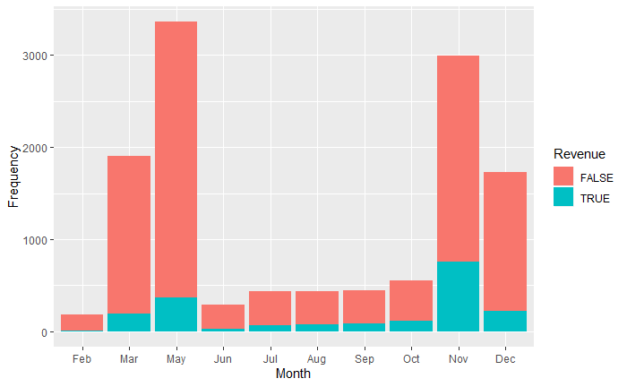

```r
dataset$Month = factor(dataset$Month, levels = month.abb)
dataset %>%
  ggplot() +
  aes(x = Month, Revenue = ..count../nrow(dataset), fill = Revenue) +
  geom_bar() +
  ylab("Frequency")
```

The plot describes the frequency of the revenue generated over the months.

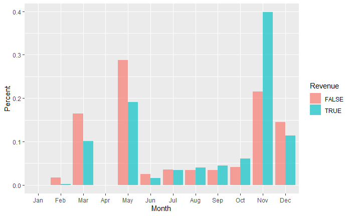

```r
table_month = table(dataset$Month, dataset$Revenue)
tab_mon =  as.data.frame(prop.table(table_month,2))
colnames(tab_mon) = c("Month", "Revenue", "perc")
ggplot(data = tab_mon, aes(x = Month, y = perc, fill = Revenue)) +
  geom_bar(stat = 'identity', position = 'dodge', alpha = 2/3) +
  xlab("Month")+
  ylab("Percent")
```

### Visitor

```r
theme_set(theme_bw())

## setting default parameters for mosaic plots
mosaic_theme = theme(axis.text.x = element_text(angle = 90,
                                                hjust = 1,
                                                vjust = 0.5),
                     axis.text.y = element_blank(),
                     axis.ticks.y = element_blank())
```

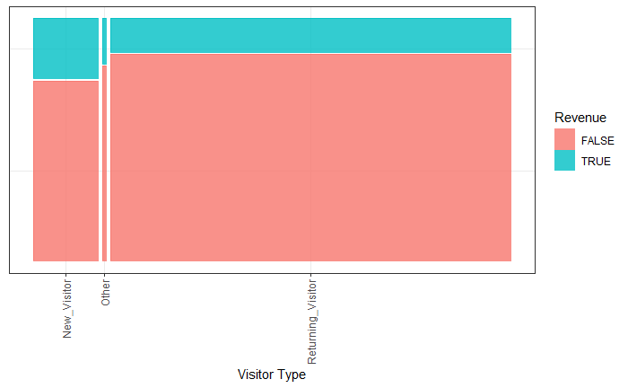

```r
dataset %>%
  ggplot() +
  geom_mosaic(aes(x = product(Revenue, VisitorType), fill = Revenue)) +
  mosaic_theme +
  xlab("Visitor Type") +
  ylab(NULL)
```

The comparison of the VisitorType which are New_Visitors, Returning_Visitor and Others with Revenue generated. There are many returning visitors in the contrast to less new visitors. Although, the new visitors have high probablity of purchasing the product and help the revenue than the returning visitors.

### Weekend

```r
CrossTable(dataset$Weekend, dataset$Revenue)
```

```
   Cell Contents
|-------------------------|
|                       N |
| Chi-square contribution |
|           N / Row Total |
|           N / Col Total |
|         N / Table Total |
|-------------------------|


Total Observations in Table:  12330


                | dataset$Revenue
dataset$Weekend |     FALSE |      TRUE | Row Total |
----------------|-----------|-----------|-----------|
          FALSE |      8053 |      1409 |      9462 |
                |     0.381 |     2.080 |           |
                |     0.851 |     0.149 |     0.767 |
                |     0.773 |     0.738 |           |
                |     0.653 |     0.114 |           |
----------------|-----------|-----------|-----------|
           TRUE |      2369 |       499 |      2868 |
                |     1.257 |     6.864 |           |
                |     0.826 |     0.174 |     0.233 |
                |     0.227 |     0.262 |           |
                |     0.192 |     0.040 |           |
----------------|-----------|-----------|-----------|
   Column Total |     10422 |      1908 |     12330 |
                |     0.845 |     0.155 |           |
----------------|-----------|-----------|-----------|
```

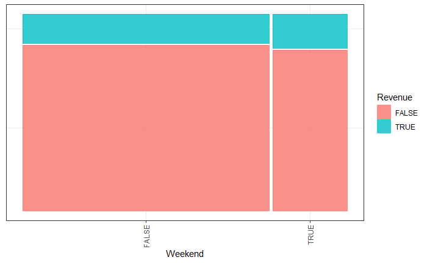

```r
dataset %>%
  ggplot() +
  mosaic_theme +
  geom_mosaic(aes(x = product(Revenue,Weekend), fill = Revenue)) +
  xlab("Weekend") +
  ylab(NULL)
```

Currently we are implemented two classification algorithms Decision Tree and K-Nearest Neighbors and achieved really good accuracies in both of them. In the next milestone we are planning to implement naive bayes and SVM.

### Decision Tree

Now preparing the dataset for the classification algorithms. Splitting the dataset into testing and training data for training the model. We will split the data in ratio 80:20.

```r
dataset_classify = dataset[-c(19:22)]
set.seed(123)
split = sample.split(dataset_classify$Revenue, SplitRatio = 0.8)
training_data = subset(dataset_classify, split == TRUE)
test_data = subset(dataset_classify, split == FALSE)
```

Running the decision tree from the “rpart” library:

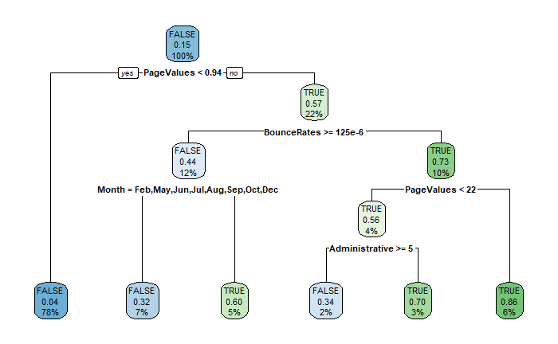

```r
dt_model<- rpart(Revenue ~ . , data = training_data, method="class")
rpart.plot(dt_model)
```

```r
dt.pred <- predict(dt_model,test_data,type = "class")
mean(dt.pred==test_data$Revenue)
```

```
[1] 0.8965937
```

Confusion Matrix for Decision Tree

```r
cfdt<-table(dt.pred,test_data$Revenue)
cfdt
```

```
dt.pred FALSE TRUE
  FALSE  1989  160
  TRUE     95  222
```

Accuracy measures for Decision Tree:

```r
dt_precision<- cfdt[1,1]/(sum(cfdt[1,]))
dt_recall<- cfdt[1,1]/(sum(cfdt[,1]))
dt_fscore <- 2*dt_precision*dt_recall/(dt_precision+dt_recall)
dt_precision
```

```
[1] 0.9255468
```

```r
dt_recall
```

```
[1] 0.9544146
```

```r
dt_fscore
```

```
[1] 0.939759
```

### KNN

Firstly, we have to prepare the data for analysis. The data preprocessing has to be done before we run any machine learning algorithm. The data preprocessing includes the preparation of the data converting from categorical data to ordinal factors. Creating Binary variables for the *Weekend* column for False as ‘0’ and True as ‘1’.

Running the KNN algorithm from the “class” package:

```r
dataset_knn <- dataset[c(1:17,19)]
dataset_knn$OperatingSystems <- factor(dataset$OperatingSystems,
                                   order = TRUE,
                                   levels = c(6,3,7,1,5,2,4,8))
dataset_knn$Browser <- factor(dataset$Browser,
                          order = TRUE,
                          levels = c(9,3,6,7,1,2,8,11,4,5,10,13,12))
dataset_knn$Region <- factor(dataset$Region,
                         order = TRUE,
                         levels = c(8,6,3,4,7,1,5,2,9))
dataset_knn$TrafficType <- factor(dataset$TrafficType,
                              order = TRUE,
                              levels = c(12,15,17,18,13,19,3,9,1,6,4,14,11,10,5,2,20,8,7,16))
dataset_knn$Month <- factor(dataset$Month,
                        levels = c('Feb', 'Mar', 'May',
                                   'Jun','Jul','Aug','Sep','Oct','Nov','Dec'),
                        labels = c(2,3,5,6,7,8,9,10,11,12))
dataset_knn$VisitorType<- factor(dataset$VisitorType,
                                      levels = c('Returning_Visitor', 'Other', 'New_Visitor'),
                                      labels = c(1,2,3))
dataset_knn$Weekend <- factor(dataset$Weekend,
                              levels = c('TRUE','FALSE'),
                              labels = c(1,0))
```

Splitting the data for the testing and training data in the ratio 80:20 for the KNN.

```r
set.seed(1233)
splitknn = sample.split(dataset_knn$Revenue_binary, SplitRatio = 0.8)
training_data_knn = subset(dataset_knn, split == TRUE)
test_data_knn = subset(dataset_knn, split == FALSE)
```

Bulding the KNN classifier as the y_pred

```r
library(class)
y_pred = knn(train = training_data_knn[, -18],
             test = test_data_knn[, -18],
             cl = training_data_knn[, 18],
             k = 5,
             prob = TRUE)
```

Building the Confusion Matrix for the K-Nearest Neighbor

```r
cm = table(test_data_knn[, 18], y_pred)
cm
```

```
   y_pred
       0    1
  0 2021   63
  1  270  112
```

Precision, Recall and F-score for KNN

```r
knn_precision<- cm[1,1]/(sum(cm[1,]))
knn_recall<- cm[1,1]/(sum(cm[,1]))
knn_fscore <- 2*knn_precision*knn_recall/(knn_precision+knn_recall)
knn_precision
```

```
[1] 0.9697697
```

```r
knn_recall
```

```
[1] 0.8821475
```

```r
knn_fscore
```

```
[1] 0.9238857
```